# Modeling Daily Disease Cases: Poisson vs Negative Binomial Regression

Chigere Adoration

2025-04-03

# Negative Binomial vs. Poisson: How to Choose a Regression Model

Negative binomial regression and Poisson regression are two types of models well-suited for discrete count outcomes—like the number of disease cases reported per day.

Here are some real-world examples of such outcomes in health research:

- The number of daily flu cases in a city
- The number of new COVID-19 cases in a hospital ward
- The number of malaria admissions in a district clinic
- The number of vaccine doses administered per week

If the variance of the count data is approximately equal to the mean, Poisson regression typically works well. However, if the variance is significantly greater than the mean (a condition known as overdispersion), Negative Binomial regression is often the better choice. How to Choose Between the Models

There are two main techniques to help decide whether a Poisson or Negative Binomial model is more appropriate:

1. Residual Plots We examine standardized residuals vs. predicted values: • If most residuals fall between -2 and 2, Poisson may be fine. • If many residuals are outside that range, especially above ±3, it suggests overdispersion, favoring the Negative Binomial model.
2. Likelihood Ratio Test (LRT) We fit both models and compare their log-likelihoods: • A small p-value (e.g., < 0.05) from the LRT indicates the Negative Binomial model offers a significantly better fit. Example: Modeling Daily Disease Cases Suppose we want to model the number of daily reported disease cases based on: • Temperature • Humidity • Population density • Vaccination rate

# Step 1: import relevant diaries

```r
library(MASS)
library(ggplot2)
library(dplyr)
```

# Step 2: Create the Data

Suppose we want to understand how environmental and demographic factors affect the number of daily reported disease cases in a region. Specifically, we’re interested in how variables like temperature, humidity, population density, and vaccination rates relate to the frequency of new cases.

The following code creates the dataset we will work with. The dataset shown here represents a subset of a larger simulated health dataset, where each row corresponds to a specific day, and the variables include environmental conditions and public health indicators used to model disease cases.

```r
set.seed(42)
n <- 200  # number of days

health_data <- data.frame(
  day = seq(as.Date("2024-01-01"), by = "day", length.out = n),
  temperature = rnorm(n, mean = 25, sd = 5),
  humidity = runif(n, min = 40, max = 90),
  pop_density = rnorm(n, mean = 5000, sd = 1500),
  vacc_rate = runif(n, min = 0.3, max = 0.9)
)

# Simulate overdispersed case counts
lambda <- exp(1 + 0.02 * health_data$temperature -
              0.01 * health_data$humidity +
              0.0001 * health_data$pop_density -
              2 * health_data$vacc_rate)

# Negative Binomial-distributed outcome
health_data$cases <- rnbinom(n, mu = lambda, size = 1.2)

head(health_data)
```

```
##          day temperature humidity pop_density vacc_rate cases
## 1 2024-01-01    31.85479 41.13500    4993.069 0.8089759     0
## 2 2024-01-02    22.17651 65.66198    6140.363 0.3376478     4
## 3 2024-01-03    26.81564 71.53631    5058.486 0.7919071     1
## 4 2024-01-04    28.16431 60.93858    6102.608 0.6236162     1
## 5 2024-01-05    27.02134 83.96330    4780.291 0.5994121     0
## 6 2024-01-06    24.46938 45.39935    4913.169 0.3133364     0
```

# Step 3: Fit Poisson and Negative Binomial Models

```r
poisson_model <- glm(cases ~ temperature + humidity + pop_density + vacc_rate,
                     family = poisson(link = "log"), data = health_data)
print(poisson_model)
```

```
##
## Call:  glm(formula = cases ~ temperature + humidity + pop_density +
##     vacc_rate, family = poisson(link = "log"), data = health_data)
##
## Coefficients:
## (Intercept)  temperature     humidity  pop_density    vacc_rate
##   1.877e+00   -1.801e-02   -3.932e-03    9.508e-05   -2.463e+00
##
## Degrees of Freedom: 199 Total (i.e. Null);  195 Residual
## Null Deviance:       432.3
## Residual Deviance: 370.8     AIC: 678.3
```

```r
nb_model <- glm.nb(cases ~ temperature + humidity + pop_density + vacc_rate,
                   data = health_data)
print(nb_model)
```

```
##
## Call:  glm.nb(formula = cases ~ temperature + humidity + pop_density +
##     vacc_rate, data = health_data, init.theta = 1.412513276,
##     link = log)
##
## Coefficients:
## (Intercept)  temperature     humidity  pop_density    vacc_rate
##   1.916e+00   -1.287e-02   -6.712e-03    9.394e-05   -2.437e+00
##
## Degrees of Freedom: 199 Total (i.e. Null);  195 Residual
## Null Deviance:       240.5
## Residual Deviance: 209.5     AIC: 630.6
```

# Step 4: Create the Residual Analysis plot

In a well-fitting model, standardized residuals generally fall within ±2. Wider ranges indicate a poor fit, often due to overdispersion.

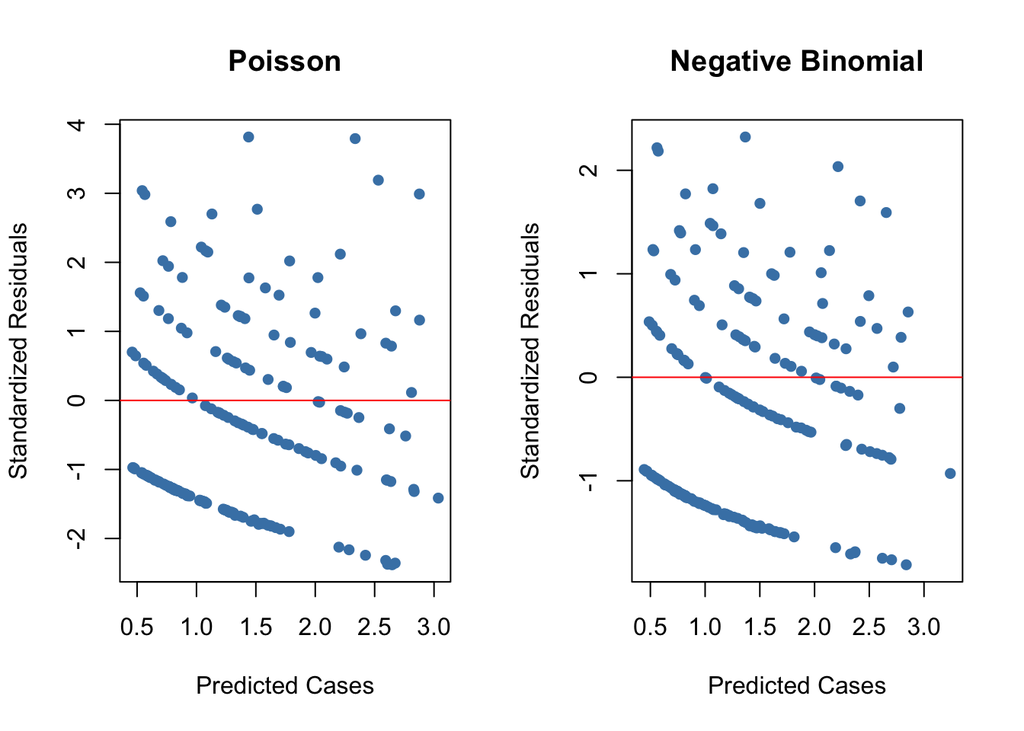

```r
par(mfrow = c(1, 2))

plot(fitted(poisson_model), rstandard(poisson_model),
     col = 'steelblue', pch = 16, main = "Poisson",
     xlab = "Predicted Cases", ylab = "Standardized Residuals")
abline(h = 0, col = "red")

plot(fitted(nb_model), rstandard(nb_model),
     col = 'steelblue', pch = 16, main = "Negative Binomial",
     xlab = "Predicted Cases", ylab = "Standardized Residuals")
abline(h = 0, col = "red")
```

From the plots, we can observe that the residuals from the Poisson regression model are more widely spread compared to those from the Negative Binomial model. In the Poisson plot, several residuals exceed +3, indicating that the model is struggling to account for variation in the data. This spread is a clear sign of overdispersion—where the variance of the count data is greater than the mean.

# Step 5: 🧪 Likelihood Ratio Test

```r
pchisq(2 * (logLik(nb_model) - logLik(poisson_model)), df = 1, lower.tail = FALSE)
```

```
## 'log Lik.' 1.711721e-12 (df=6)
```

The p-value of the likelihood ratio test turned out to be 1.711721e-12, which is extremely small and well below the standard significance level of 0.05. This indicates that the Negative Binomial regression model provides a statistically significantly better fit to the data than the Poisson regression model.

# Conclusion

In this analysis, we compared Poisson and Negative Binomial regression models to evaluate which better fits daily disease case counts influenced by environmental and population-level factors.

The Poisson model showed signs of overdispersion, as evidenced by widely scattered residuals, including values exceeding +3.

The Negative Binomial model demonstrated a tighter spread of residuals, indicating a better fit for the data.

The Likelihood Ratio Test produced a p-value of 1.711721e-12, providing strong statistical evidence that the Negative Binomial model outperforms the Poisson model.

Given both visual and statistical confirmation, we conclude that the Negative Binomial regression model is more appropriate for modeling our overdispersed count data and provides more reliable estimates in public health settings.

This analysis underscores the importance of checking for overdispersion when working with count data—and selecting models that can handle it effectively.